# TPG UAS Mandiri

Rahmandani Bardianto G1401231029

2025-11-25

# 1 Pre Drocessing Data

## 1.1 Import data

```r
df = read.csv("C:/Users/PC/Downloads/0_df_long.csv")
```

## 1.2 Memeriksa Na

```r
colSums(is.na(df))
```

```
##   KabKot    Tahun    Bulan   Produk    Harga Kategori  KodeBPS KodeProv
##        0        0        0        0    61513        0        0        0
## NamaProv
##     3450
```

## 1.3 Menangani Na kolom Nama Provinsi

```r
unique(df$NamaProv)
```

```
##  [1] "Aceh"                      "Sumatera Barat"
##  [3] "Nusa Tenggara Timur"       "Sumatera Utara"
##  [5] "Bali"                      "Kalimantan Selatan"
##  [7] "Jawa Barat"                "Sulawesi Tengah"
##  [9] "Kepulauan Bangka Belitung" "Jawa Timur"
## [11] "Jawa Tengah"               "Sulawesi Selatan"
## [13] "DI Yogyakarta"             "Sumatera Selatan"
## [15] "Kalimantan Tengah"         "Jambi"
## [17] "Riau"                      "Kalimantan Barat"
## [19] "Bengkulu"                  "Kalimantan Timur"
## [21] "Papua Barat"               "Nusa Tenggara Barat"
## [23] "Kepulauan Riau"            "Gorontalo"
## [25] "Sulawesi Utara"            "Sulawesi Tenggara"
## [27] NA                          "Maluku"
## [29] "Papua"                     "Maluku Utara"
## [31] "DKI Jakarta"               "Lampung"
## [33] "Banten"                    "Sulawesi Barat"
```

```r
# Mengisi NA pada klom NamaProv berdasarkn KodeProv dari BPS
library(dplyr)
prov_ref = tribble(
  ~KodeProv, ~NamaProv,
  11, "Aceh",
  12, "Sumatera Utara",
  13, "Sumatera Barat",
  14, "Riau",
  15, "Jambi",
  16, "Sumatera Selatan",
  17, "Bengkulu",
  18, "Lampung",
  19, "Kepulauan Bangka Belitung",
  21, "Kepulauan Riau",
  31, "DKI Jakarta",
  32, "Jawa Barat",
  33, "Jawa Tengah",
  34, "DI Yogyakarta",
  35, "Jawa Timur",
  36, "Banten",
  51, "Bali",
  52, "Nusa Tenggara Barat",
  53, "Nusa Tenggara Timur",
  61, "Kalimantan Barat",
  62, "Kalimantan Tengah",
  63, "Kalimantan Selatan",
  64, "Kalimantan Timur",
  65, "Kalimantan Utara",
  71, "Sulawesi Utara",
  72, "Sulawesi Tengah",
  73, "Sulawesi Selatan",
  74, "Sulawesi Tenggara",
  75, "Gorontalo",
  76, "Sulawesi Barat",
  81, "Maluku",
  82, "Maluku Utara",
  91, "Papua Barat",
  94, "Papua"
)

df_fix = df %>%
  left_join(prov_ref, by = "KodeProv", suffix = c("", "_ref")) %>%
  mutate(
    NamaProv = if_else(
      is.na(NamaProv),
      NamaProv_ref,
      NamaProv
    )
  ) %>%
  select(-NamaProv_ref)

colSums(is.na(df_fix))
```

```
##   KabKot    Tahun    Bulan   Produk    Harga Kategori  KodeBPS KodeProv
##        0        0        0        0    61513        0        0        0
## NamaProv
##        0
```

*Interpretasi* Data masih menggunakan daftar provinsi lama yang berjumlah 34. Kolom nama provinsi terdapat beberapa NA, untuk menangani NA tersebut saya lakukan pengisian nama provinsi berdasarkan Kode provinsi karena kolom kode provinsi tidak terdapat Na.

## 1.4 Menangani NA pada Kolom Harga

```r
library(dplyr)
library(zoo)
bulan_order = c("Januari","Februari","Maret","April","Mei","Juni",
                "Juli","Agustus","September","Oktober","November","Desember")

df2 = df_fix %>%
  mutate(
    bulan_num = match(Bulan, bulan_order),
    tanggal   = as.Date(paste(Tahun, bulan_num, 1, sep = "-"))
  ) %>%
  arrange(KabKot, Produk, tanggal)

df2 = df2 %>%
  group_by(KabKot, Produk) %>%
  mutate(
    harga_interp = na.approx(Harga, x = tanggal, na.rm = FALSE)
  ) %>%
  ungroup()

df2 = df2 %>%
  group_by(KabKot, Produk) %>%
  mutate(
    mean_kab = if (all(is.na(Harga))) NA_real_ else mean(Harga, na.rm = TRUE)
  ) %>%
  ungroup() %>%
  group_by(KodeProv, Produk) %>%
  mutate(
    mean_prov = if (all(is.na(Harga))) NA_real_ else mean(Harga, na.rm = TRUE)
  ) %>%
  ungroup() %>%
  group_by(Produk) %>%
  mutate(
    mean_nat = if (all(is.na(Harga))) NA_real_ else mean(Harga, na.rm = TRUE)
  ) %>%
  ungroup()


df2 = df2 %>%
  mutate(
    Harga_impute = case_when(
      !is.na(Harga)        ~ Harga,        #harga asli
      !is.na(harga_interp) ~ harga_interp, # interpolasi linear (dari 2 waktu)
      !is.na(mean_kab)     ~ mean_kab,     #rata kabupten
      !is.na(mean_prov)    ~ mean_prov,    # rata povinsi
      !is.na(mean_nat)     ~ mean_nat,     #rata nasional
      TRUE                 ~ NA_real_
    )
  ) %>%
  select(-bulan_num, -tanggal, -harga_interp, -mean_kab, -mean_prov, -mean_nat)


df_final = df2 %>%
  mutate(Harga = Harga_impute) %>%
  select(-Harga_impute)


colSums(is.na(df_final))
```

```
##   KabKot    Tahun    Bulan   Produk    Harga Kategori  KodeBPS KodeProv
##        0        0        0        0        0        0        0        0
## NamaProv
##        0
```

*Interpretasi* Pengisian harga yang hilang dilakukan bertahap agar pola waktu dan wilayah tetap terjaga. Pertama, setiap KabKot × Produk diurutkan berdasarkan bulan, lalu harga yang kosong diisi dengan interpolasi waktu (linear) jika ada nilai sebelum–sesudahnya. Jika interpolasi tidak memungkinkan (misalnya deretnya terlalu banyak NA di awal atau akhir), maka mengggunakan rata-rata kabupaten untuk produk tersebut. Jika kabupaten tidak punya data sama sekali, barulah dipakai rata-rata provinsi, dan jika provinsi juga kosong, digunakan rata-rata nasional sebagai langkah terakhir.

# 2 Time Series Clustering

## 2.1 Menyiapkan data deret waktu dan mencari jumlah cluster optimal

```r
library(tidyr)

bulan_order = c("Januari","Februari","Maret","April","Mei","Juni",
                "Juli","Agustus","September","Oktober","November","Desember")

df_ts = df_final %>%
  mutate(
    bulan_num = match(Bulan, bulan_order),
    time_id = (Tahun - min(Tahun)) * 12 + bulan_num
  ) %>%
  arrange(Produk, time_id)


df_nat = df_ts %>%
  group_by(Produk, time_id) %>%
  summarise(Harga = mean(Harga, na.rm = TRUE), .groups = "drop")



mat = df_nat %>%
  pivot_wider(names_from = time_id, values_from = Harga) %>%
  arrange(Produk)



mat_scaled = t(scale(t(as.matrix(mat[,-1]))))
rownames(mat_scaled) = mat$Produk



library(factoextra)
```

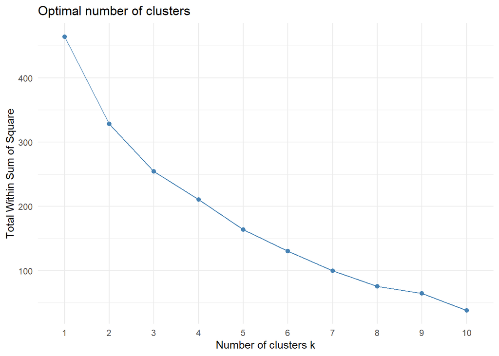

```r
fviz_nbclust(mat_scaled, kmeans, method = "wss") +
  theme_minimal()
```

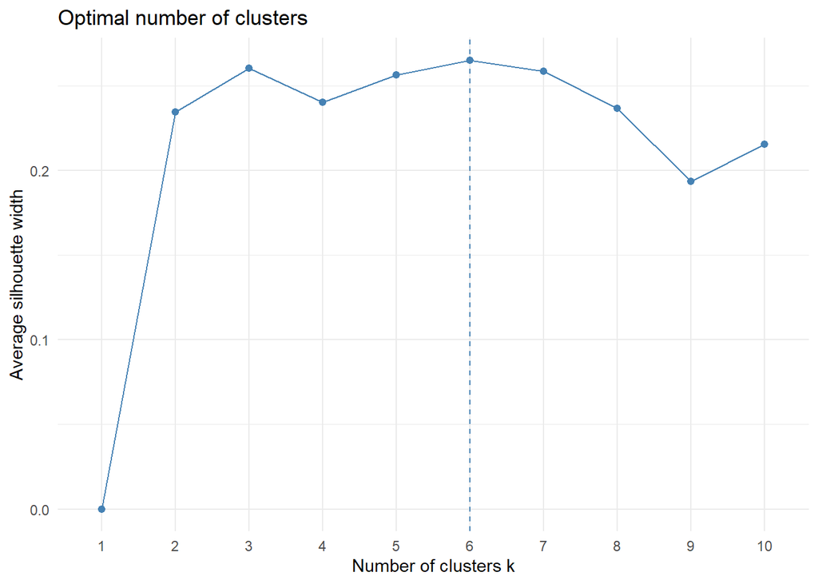

```r
fviz_nbclust(mat_scaled, kmeans, method = "silhouette") +
  theme_minimal()
```

*Interpretasi* Proses ini mengubah data harga menjadi deret waktu yang tersusun rapi untuk setiap produk, lalu merata-ratakannya secara nasional agar pola pergerakan harga lebih jelas. Deret waktu tiap produk kemudian disusun dalam bentuk matriks dan distandarisasi supaya perbandingan antar produk hanya melihat bentuk polanya, bukan besarnya harga. Setelah struktur data siap, dua metode penentuan jumlah cluster, Elbow dan Silhouettedigunakan untuk mencari jumlah kelompok pola harga yang paling stabil dan paling tepat sebelum dilakukan clustering.